# Psychology and Human Behavior

Week 7 Monday — The person and the situation

NRES 315: Human Dimensions of Fish and Wildlife Management

2026-10-05

## “They just need to care more”

You will hear this sentence in a management meeting. It is almost always wrong — not because caring is irrelevant, but because the people in question usually already care.

This week asks what else has to be true before a person acts.

Source: Chapter 8, §8.2

## Today’s question

What does psychology add once we already know that people support a conservation goal?

Source: Chapter 8, §8.2

## What you should be able to do

By the end of today, you should be able to:

- distinguish **cognition**, **conation**, and **affect**;
- explain the **person** and the **situation** as two interacting lenses;
- explain the **cognitive hierarchy** from values to specific behavior; and
- state the **specificity principle** and why it matters for prediction.

Source: Chapter 8, §§8.3–8.4.1

## What psychology is for

It connects individual thought and behavior to practical management problems.

Source: Chapter 8, §8.2

## Five jobs psychology does in management

- **Designing interventions** — targeting the actual drivers of action.
- **Enhancing participation** — uncovering what motivates or discourages different publics.
- **Managing conflict** — understanding the roots of conflict among people, groups, and institutions.
- **Contextual planning** — making plans relevant to local communities.
- **Informing decisions** — cognitive biases, emotions, bounded rationality, and uncertainty.

Source: Chapter 8, §8.2

## A caution before we start

Most classic disciplines, psychology included, emerged within Western cultures and ways of knowing. There is often an implicit assumption that those concepts apply universally.

**Cultural relevance:** the degree to which a practice, intervention, or program is tailored to the specific cultural backgrounds, values, and experiences of a community.

Source: Chapter 8, §8.2.1

## Three components of mental life

Cognition · conation · affect

*Thinking, motivation, and emotion shape how we understand and respond to the world.*

Source: Chapter 8, §8.3

## Cognition, conation, affect

Motivational and volitional drive: will, intent, striving

| Component | What it is | A question that reveals it |
| --- | --- | --- |
| **Cognition** | Mental processes: perception, reasoning, memory | “Do you think draining your boat makes a difference?” |
| **Conation** | Motivational and volitional drive: will, intent, striving | “Do you intend to do it on your next trip?” |
| **Affect** | The experience of emotions and feelings | “How do you feel when you see the agency’s sign?” |

These interact to form internal states — beliefs and attitudes — which then appear as observable decisions and actions.

Source: Chapter 8, §8.3

## The person and the situation

**The person**

Intrapersonal factors. Internal explanations for thought and behavior.

**The situation**

Interpersonal and situational factors. The social or biophysical structures that explain thought and behavior.

The person and the situation are **inseparable**. Social and cognitive psychology explain behavior by analyzing how the two interact.

Source: Chapter 8, §8.3

## A worked contrast

A landowner **wants** to secure bear attractants but has nowhere secure to store them.

Diagnosing this as a values problem produces a brochure.

Diagnosing it as a situational constraint produces storage.

The same observed behavior — attractants left out — supports two completely different interventions. Only one of them can work.

Source: Chapter 8, §8.3

## The cognitive hierarchy

How broad beliefs and values connect to specific attitudes and behaviors

*From abstract and stable to specific and situational.*

Source: Chapter 8, §8.4.1 and Box 8.5

## From values to behavior

- **Values** are few, abstract, and stable across a life.
- **Value orientations** are patterns among basic beliefs — the link between abstract values and specific cognitions.
- **Attitudes and norms** are specific to an object or an action.
- **Intention** is the most immediate predictor of behavior.

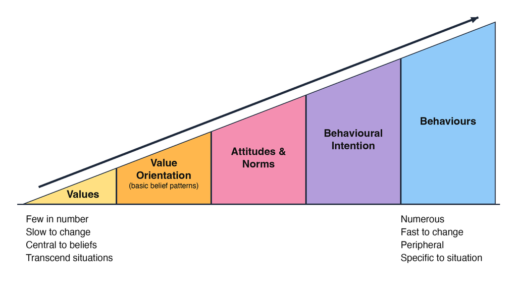

Source: Chapter 8, §8.4.1, Figure 8.1, and Box 8.5

## Wildlife value orientations in the U.S.

**Domination:** wildlife should be managed for human benefit.

**Mutualism:** wildlife are part of our social community and deserve care.

**Two orientations, four types:**

- **Traditionalists:** high domination, low mutualism.
- **Mutualists:** high mutualism, low domination.
- **Pluralists:** high on both.
- **Distanced:** low on both.

**Percent Mutualists by state, 2018**

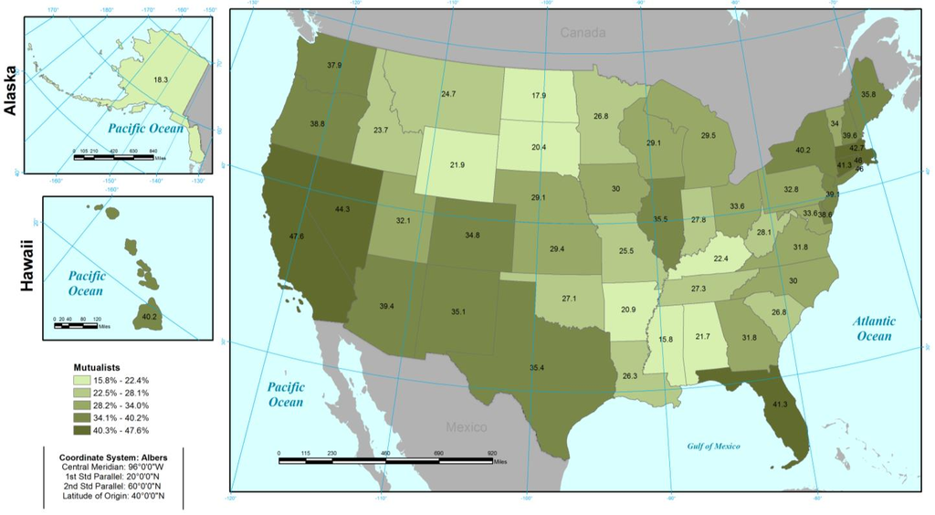

**Nebraska: 29% · California: 48% · Wyoming: 22%**

National survey: 43,949 respondents across all 50 states.

Source: CSU, America’s Wildlife Values national report (2018 data), pp 13–15, Map 2; Teel and Manfredo (2009)

## Wildlife values across Europe and the Americas

**33 countries · 18,477 respondents · 2021–2023**

Mutualism was more prevalent in Iberian-origin Latin America; domination was more prevalent in British-origin North America.

**Read the panels separately:** a person can score high on both orientations.

Gray areas were not surveyed.

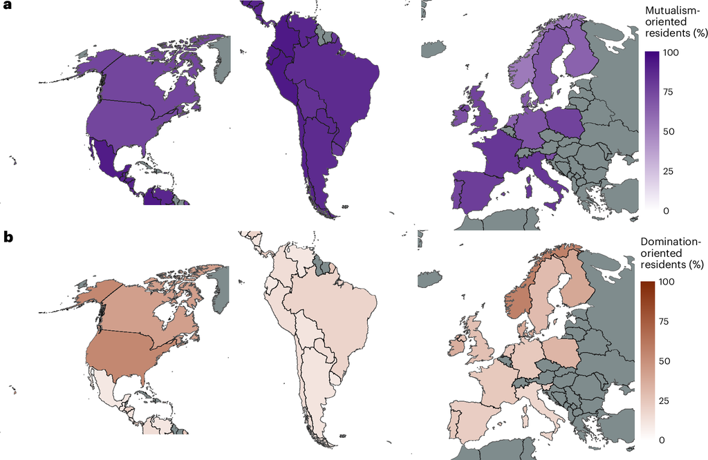

Source: Manfredo, Teel, and colleagues (2026), Nature Sustainability, Figure 1

## The specificity principle

Correlations between variables are larger when the variables **correspond** in target, action, context, and time.

An orientation describes broad beliefs about wildlife; a particular hunting decision is much more specific.

- Wildlife value orientations predict **general** acceptability of hunting well.
- They predict **archery hunting** [action] **a white-tailed deer** [target] **in a suburban neighborhood** [context] **in fall 2027** [time] far less well.

If you want to predict a specific behavior, you must measure something equally specific.

Source: Chapter 8, Box 8.5

## Pair rehearsal: sort the evidence

With a partner, label each as **cognition**, **conation**, or **affect**:

1. “I don’t think one person draining a boat matters.”
2. “I feel blamed every time I read one of those signs.”
3. “I plan to do it next time I’m out.”
4. “Invasive mussels would ruin this lake.”

Source: Chapter 8, §8.3

## Wednesday and Friday

**Wednesday:** the frameworks — reasoned action and TACT, collective action and norms, emotions, motivation and satisfaction.

**Before Friday:** read the **Week 07 Case Brief: The Thornapple Lake Decontamination Problem**. It is a separate document in the Canvas module and is required preparation.

Source: Chapter 8, §§8.4–8.4.5

## Close

Psychology does not tell you what people should do. It tells you which part of the chain between belief and action is actually broken — which is what determines whether your intervention has any chance.

Source: Chapter 8, §8.5